# Applied Sciences Resubmission — Reproducibility Report

Exploratory pediatric GCF FTIR variation, partition stability, sex-associated variation, and clean-strip sensitivity

Published

October 14, 2026

# 1. Scope and computational contract

This report documents the complete pediatric-only computational chain used for the reframed manuscript. It consumes the frozen outputs of scripts `01` through `07`; it does not fit an additional model, select a new partition, or introduce a new inferential branch.

The active matrix contains **25 participant-level spectra** and **793 retained spectral variables**. The report verifies the publication tables, figures, supplementary exports, and participant-level transition records generated by the analytical workflow.

Automated scope and completeness checks performed before report rendering.

| check | expected | observed | passed |
| --- | --- | --- | --- |
| Pediatric active spectra | 25 | 25 | TRUE |
| Spectral-variable count | 793 | 793 | TRUE |
| Participant transition rows | 25 | 25 | TRUE |
| Continuous loading rows | 793 | 793 | TRUE |
| Publication manifest rows | 30 | 30 | TRUE |
| All manifest paths exist | TRUE | TRUE | TRUE |

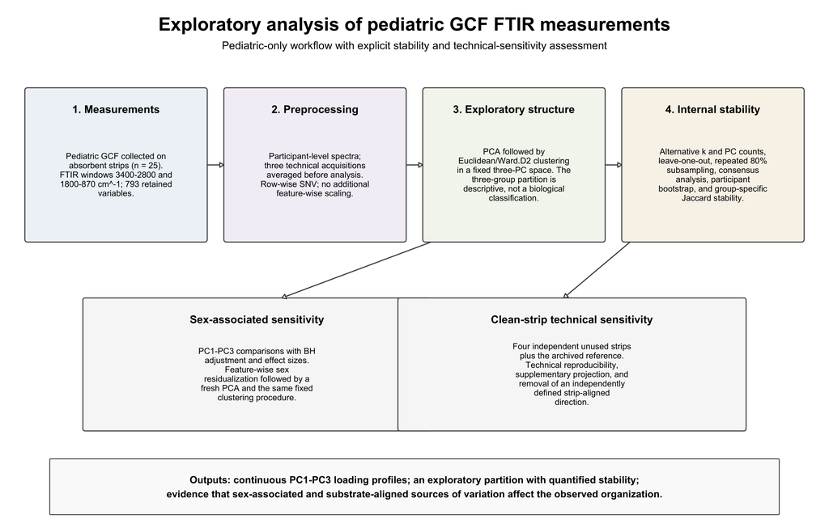

Pediatric-only exploratory analytical workflow.

# 2. Data and preprocessing

The analysis uses the spectral windows **3400–2800 cm<sup>-1</sup>** and **1800–870 cm<sup>-1</sup>**. Three technical acquisitions were averaged before participant-level analysis. Row-wise standard normal variate normalization was applied, with no additional feature-wise scaling.

Pediatric cohort characteristics used in the active analysis.

| Characteristic | Category | Value |
| --- | --- | --- |
| Age, years | Mean +/- SD | 11.92 +/- 3.37 |
| Age range, years | Minimum-maximum | 6-17 |
| Sex | Female | 12 (48.0%) |
| Sex | Male | 13 (52.0%) |
| Pubertal development | Normal | 8 (32.0%) |
| Pubertal development | Early | 3 (12.0%) |
| Pubertal development | Delayed | 1 (4.0%) |
| Pubertal development | Unknown / insufficient information | 13 (52.0%) |
| Endocrine status | Documented pathology | 19 (76.0%) |
| Endocrine status | No documented pathology | 5 (20.0%) |
| Endocrine status | Unknown | 1 (4.0%) |
| UCTD status | Documented pathology | 22 (88.0%) |
| UCTD status | No documented pathology | 3 (12.0%) |
| Periodontal status | Documented pathology | 3 (12.0%) |
| Periodontal status | No documented pathology | 22 (88.0%) |

```r
preprocessing_checks <- tibble::tibble(
  Check = c(
    "Raw matrix dimensions",
    "SNV matrix dimensions",
    "Maximum absolute SNV row mean",
    "Maximum absolute SNV row SD minus 1",
    "Wavenumber count"
  ),
  Value = c(
    paste(dim(X_raw), collapse = " x "),
    paste(dim(X_snv), collapse = " x "),
    format(max(abs(rowMeans(X_snv))), scientific = TRUE, digits = 4),
    format(max(abs(apply(X_snv, 1, stats::sd) - 1)), scientific = TRUE, digits = 4),
    as.character(length(wavenumbers))
  )
)

kable_clean(preprocessing_checks)
```

| Check | Value |
| --- | --- |
| Raw matrix dimensions | 25 x 793 |
| SNV matrix dimensions | 25 x 793 |
| Maximum absolute SNV row mean | 6.681e-15 |
| Maximum absolute SNV row SD minus 1 | 1.776e-15 |
| Wavenumber count | 793 |

# 3. Spectral structure and baseline exploratory partition

PC1, PC2, and PC3 explain **48.28%**, **32.37%**, and **8.64%** of total spectral variance, respectively. Together they explain **89.28%**. The fixed three-PC representation yields exploratory groups of **15/4/6** participants.

The loading profiles retain the raw mathematical signs produced by PCA. No post hoc sign orientation is applied.

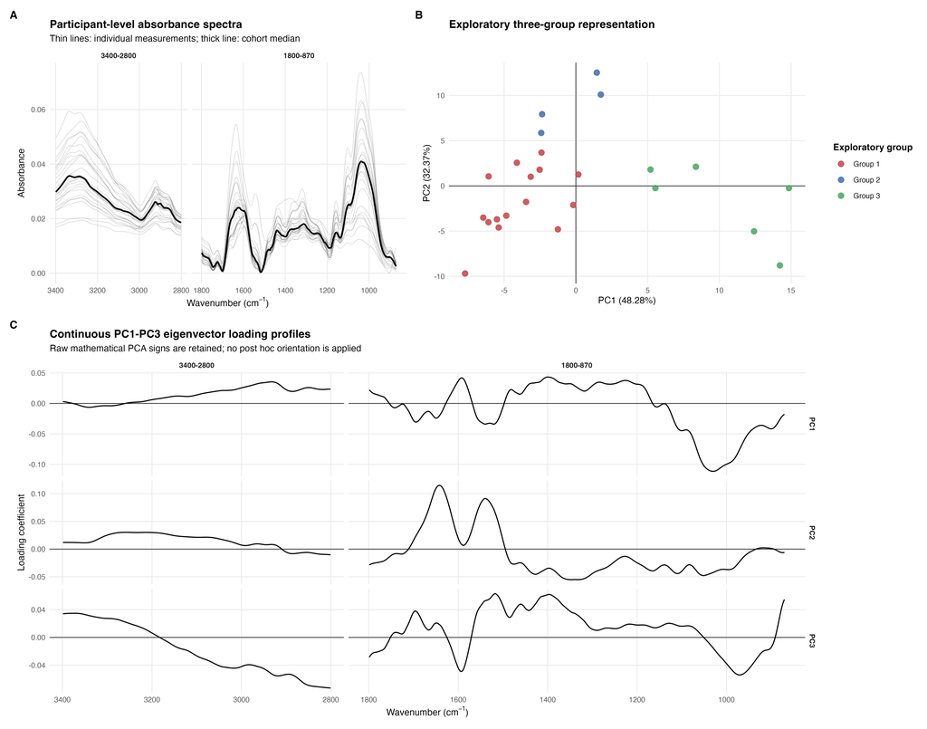

Participant spectra, exploratory PCA score representation, and continuous PC1–PC3 eigenvector loading profiles.

| Metric | Value |
| --- | --- |
| PC1 variance (%) | 48.276 |
| PC2 variance (%) | 32.370 |
| PC3 variance (%) | 8.635 |
| Cumulative PC1-PC3 variance (%) | 89.282 |
| Exploratory group sizes | 15/4/6 |
| Average silhouette | 0.434 |

## Continuous loading export

The full **793 × 3** loading matrix is exported as `supplement/TableS7_PCA_eigenvector_loadings_PC1_PC3.csv`. The table below lists the eight largest absolute loading coefficients on each component solely as a compact numerical audit of the continuous profiles.

```r
loading_top <- S7 |>
  tidyr::pivot_longer(
    cols = c(PC1, PC2, PC3),
    names_to = "PC",
    values_to = "loading"
  ) |>
  dplyr::mutate(abs_loading = abs(loading)) |>
  dplyr::group_by(PC) |>
  dplyr::slice_max(abs_loading, n = 8, with_ties = FALSE) |>
  dplyr::arrange(PC, dplyr::desc(abs_loading)) |>
  dplyr::ungroup() |>
  dplyr::select(PC, wavenumber, loading, abs_loading)

kable_clean(
  loading_top,
  digits = 6,
  caption = "Largest absolute loading coefficients for numerical verification only."
)
```

Largest absolute loading coefficients for numerical verification only.

| PC | wavenumber | loading | abs_loading |
| --- | --- | --- | --- |
| PC1 | 1030.704 | -0.111403 | 0.111403 |
| PC1 | 1028.774 | -0.111370 | 0.111370 |
| PC1 | 1032.634 | -0.111250 | 0.111250 |
| PC1 | 1026.844 | -0.111147 | 0.111147 |
| PC1 | 1034.565 | -0.110924 | 0.110924 |
| PC1 | 1024.914 | -0.110738 | 0.110738 |
| PC1 | 1036.495 | -0.110442 | 0.110442 |
| PC1 | 1022.984 | -0.110155 | 0.110155 |
| PC2 | 1642.564 | 0.115119 | 0.115119 |
| PC2 | 1640.634 | 0.114978 | 0.114978 |
| PC2 | 1644.495 | 0.114607 | 0.114607 |
| PC2 | 1638.704 | 0.114167 | 0.114167 |
| PC2 | 1646.425 | 0.113419 | 0.113419 |
| PC2 | 1636.774 | 0.112638 | 0.112638 |
| PC2 | 1648.355 | 0.111521 | 0.111521 |
| PC2 | 1634.844 | 0.110378 | 0.110378 |
| PC3 | 2800.659 | -0.072915 | 0.072915 |
| PC3 | 2802.589 | -0.072821 | 0.072821 |
| PC3 | 2804.519 | -0.072731 | 0.072731 |
| PC3 | 2806.450 | -0.072638 | 0.072638 |
| PC3 | 2808.380 | -0.072537 | 0.072537 |
| PC3 | 2810.310 | -0.072426 | 0.072426 |
| PC3 | 2812.240 | -0.072308 | 0.072308 |
| PC3 | 2814.170 | -0.072184 | 0.072184 |

# 4. Partition selection and internal stability

The three-group solution is retained as a parsimonious descriptive representation rather than a uniquely established classification. Internal indices were evaluated for **k = 2–6**, and sensitivity to the retained PCA dimensionality was assessed for **2–7 components**.

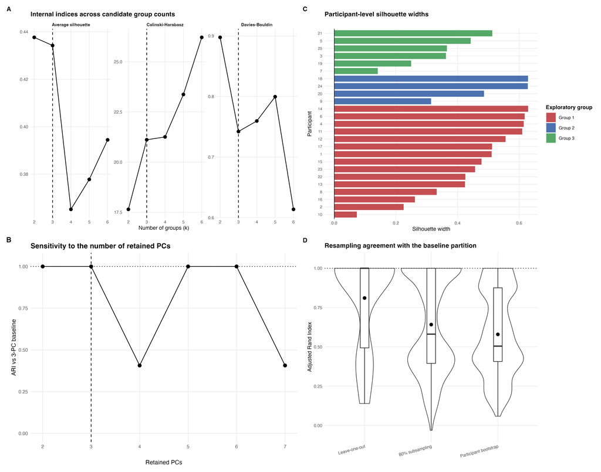

Candidate group counts, PCA-dimensionality sensitivity, leave-one-out stability, repeated subsampling, and participant bootstrap.

Summary of the exploratory partition and its internal stability.

| Analysis | Metric | Value |
| --- | --- | --- |
| Baseline representation | Participants | 25 |
| Baseline representation | Spectral variables | 793 |
| Baseline representation | Retained principal components | 3 |
| Baseline representation | Cumulative variance explained (%) | 89.28 |
| Baseline representation | Exploratory group sizes | 15/4/6 |
| Baseline representation | Average silhouette | 0.434 |
| PCA dimensionality sensitivity | Tested PC counts | 2, 3, 4, 5, 6, 7 |
| PCA dimensionality sensitivity | PC counts reproducing the baseline partition | 2, 3, 5, 6 |
| PCA dimensionality sensitivity | Number reproducing the baseline partition | 4 |
| Leave-one-out | Mean ARI | 0.811 |
| Leave-one-out | Median ARI | 1.000 |
| Leave-one-out | Exact recovery (%) | 68.0 |
| Repeated 80% subsampling | Mean ARI | 0.642 |
| Repeated 80% subsampling | Median ARI | 0.581 |
| Repeated 80% subsampling | Within-group mean consensus | 0.749 |
| Repeated 80% subsampling | Between-group mean consensus | 0.115 |
| Participant bootstrap | Mean ARI | 0.579 |
| Participant bootstrap | Median ARI | 0.505 |
| Participant bootstrap | Exact recovery (%) | 11.9 |
| Participant bootstrap | Group 1 mean Jaccard | 0.754 |
| Participant bootstrap | Group 2 mean Jaccard | 0.534 |
| Participant bootstrap | Group 3 mean Jaccard | 0.819 |

## Sensitivity to retained PCA dimensionality

```r
kable_clean(
  robustness$pc_results,
  digits = 4,
  caption = "Agreement of three-group solutions obtained with 2–7 retained principal components."
)
```

Agreement of three-group solutions obtained with 2–7 retained principal components.

| n_PC | cumulative_variance_percent | ARI_vs_baseline_3PC | identical_to_baseline | cluster_sizes |
| --- | --- | --- | --- | --- |
| 2 | 80.6468 | 1.0000 | TRUE | 15/4/6 |
| 3 | 89.2818 | 1.0000 | TRUE | 15/4/6 |
| 4 | 95.6724 | 0.4071 | FALSE | 8/11/6 |
| 5 | 97.5755 | 1.0000 | TRUE | 15/4/6 |
| 6 | 98.4320 | 1.0000 | TRUE | 15/4/6 |
| 7 | 99.1567 | 0.4071 | FALSE | 8/11/6 |

## Leave-one-out, repeated subsampling, and participant bootstrap

Across the 25 leave-one-out runs, mean ARI is **0.811**, median ARI is **1.000**, and exact recovery occurs in **68.0%** of runs.

Across 1,000 repeated 80% subsamples, mean ARI is **0.642** and median ARI is **0.581**. Mean pairwise consensus is **0.749** within baseline groups and **0.115** between baseline groups.

Across 1,000 participant-bootstrap iterations, mean ARI is **0.579**. Group-specific mean Jaccard similarities are **0.754, 0.534, 0.819** for Groups 1–3.

```r
resampling_summary <- dplyr::bind_rows(
  tibble::tibble(
    Procedure = "Leave-one-out",
    Mean_ARI = robustness$loo_summary$mean_ARI,
    Median_ARI = robustness$loo_summary$median_ARI,
    Exact_recovery_percent = 100 * robustness$loo_summary$proportion_ARI_1
  ),
  tibble::tibble(
    Procedure = "Repeated 80% subsampling",
    Mean_ARI = robustness$subsampling_summary$mean_ARI,
    Median_ARI = robustness$subsampling_summary$median_ARI,
    Exact_recovery_percent = 100 * robustness$subsampling_summary$proportion_ARI_1
  ),
  tibble::tibble(
    Procedure = "Participant bootstrap",
    Mean_ARI = robustness$bootstrap_summary$mean_ARI,
    Median_ARI = robustness$bootstrap_summary$median_ARI,
    Exact_recovery_percent = 100 * robustness$bootstrap_summary$proportion_ARI_1
  )
)

kable_clean(resampling_summary, digits = 3)
```

| Procedure | Mean_ARI | Median_ARI | Exact_recovery_percent |
| --- | --- | --- | --- |
| Leave-one-out | 0.811 | 1.000 | 68.0 |
| Repeated 80% subsampling | 0.642 | 0.581 | 32.6 |
| Participant bootstrap | 0.579 | 0.505 | 11.9 |

# 5. Sex-associated spectral variation

Sex is associated with the baseline exploratory partition (Fisher p = **0.003**; Cramer’s V = **0.640**, 95% bootstrap interval **0.414–0.919**).

Among the three planned PC comparisons, PC1 shows the strongest sex-associated difference (raw p = **0.016**; BH-adjusted p = **0.048**; rank-biserial correlation = **-0.564**; Hedges g = **-1.174**).

After feature-wise sex residualization, agreement with the baseline partition is **ARI = 0.134**. The aligned residualized group sizes are **8/14/3**, and **10** participants change aligned assignment.

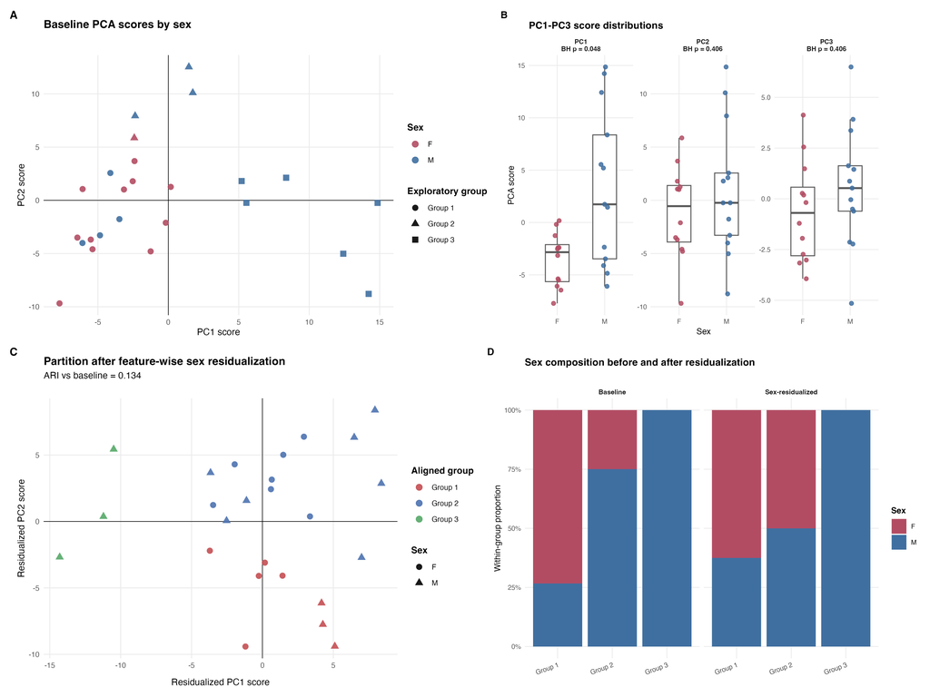

Sex-associated variation and the partition obtained after feature-wise sex residualization.

Sex associations for PC1–PC3 with Benjamini–Hochberg adjustment and effect sizes.

| PC | n_F | n_M | mean_F | mean_M | median_F | median_M | wilcoxon_W | p_value_raw | hodges_lehmann_F_minus_M | hodges_lehmann_ci_lower | hodges_lehmann_ci_upper | rank_biserial_F_vs_M | rank_biserial_ci_lower | rank_biserial_ci_upper | hedges_g_F_minus_M | hedges_g_ci_lower | hedges_g_ci_upper | p_value_BH | significant_BH_0_05 |
| --- | --- | --- | --- | --- | --- | --- | --- | --- | --- | --- | --- | --- | --- | --- | --- | --- | --- | --- | --- |
| PC1 | 12 | 13 | -3.5749 | 3.2999 | -2.8366 | 1.7366 | 34 | 0.0160 | -6.0890 | -12.5989 | -1.2331 | -0.5641 | -0.8846 | -0.1538 | -1.1743 | -2.0756 | -0.6156 | 0.0479 | TRUE |
| PC2 | 12 | 13 | -1.1424 | 1.0545 | -0.5474 | -0.2350 | 62 | 0.4059 | -1.3066 | -6.6061 | 2.8263 | -0.2051 | -0.6282 | 0.2564 | -0.3960 | -1.1564 | 0.3662 | 0.4059 | FALSE |
| PC3 | 12 | 13 | -0.6316 | 0.5830 | -0.6956 | 0.5276 | 58 | 0.2945 | -1.3014 | -3.5758 | 0.9534 | -0.2564 | -0.6795 | 0.2051 | -0.4253 | -1.2782 | 0.3326 | 0.4059 | FALSE |

# 6. Clean-strip technical reproducibility and sensitivity

The four independent unused strips show very high reproducibility: minimum pairwise Pearson r = **0.999989**, minimum pairwise Spearman rho = **0.999982**, integrated-absorbance CV = **0.819%**, median pointwise CV = **0.854%**, and 95th-percentile pointwise CV = **1.174%**.

Removing the direction defined by the mean of the four independent strips changes the exploratory partition to **ARI = 0.407** relative to baseline; **7** participants change aligned assignment. This procedure is treated as a sensitivity analysis, not as a corrected biological partition.

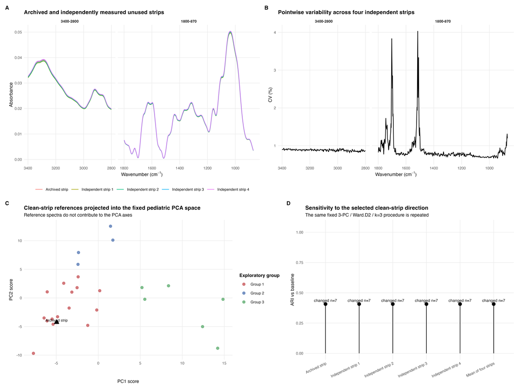

Clean-strip reproducibility, supplementary projection, and sensitivity to removal of the independently defined strip-aligned direction.

```r
kable_clean(
  S3,
  digits = 6,
  caption = "Technical reproducibility of the four independent unused strips."
)
```

Technical reproducibility of the four independent unused strips.

| metric | value |
| --- | --- |
| Minimum pairwise Pearson | 0.999989 |
| Median pairwise Pearson | 0.999996 |
| Minimum pairwise Spearman | 0.999982 |
| Median pairwise Spearman | 0.999990 |
| Integrated absorbance CV (%) | 0.818766 |
| Median pointwise CV (%) | 0.854203 |
| 95th percentile pointwise CV (%) | 1.174046 |
| Archived strip vs four-strip mean Pearson | 0.999999 |
| Archived strip vs four-strip mean Spearman | 0.999996 |
| Maximum DPT-vs-archived grid difference (cm^-1) | 0.000005 |

```r
kable_clean(
  S4,
  digits = 4,
  caption = "Sensitivity results obtained using each independently defined clean-strip direction."
)
```

Sensitivity results obtained using each independently defined clean-strip direction.

| reference | ARI_vs_baseline | changed_participants | cumulative_variance_3PC_percent | average_silhouette | negative_silhouette_count | cluster_1_n | cluster_2_n | cluster_3_n |
| --- | --- | --- | --- | --- | --- | --- | --- | --- |
| archived_clean_strip | 0.4071 | 7 | 89.8265 | 0.3713 | 2 | 8 | 11 | 6 |
| strip_01 | 0.4071 | 7 | 89.8186 | 0.3713 | 2 | 8 | 11 | 6 |
| strip_02 | 0.4071 | 7 | 89.8163 | 0.3713 | 2 | 8 | 11 | 6 |
| strip_03 | 0.4071 | 7 | 89.8331 | 0.3713 | 2 | 8 | 11 | 6 |
| strip_04 | 0.4071 | 7 | 89.8271 | 0.3712 | 2 | 8 | 11 | 6 |
| mean_four_strips | 0.4071 | 7 | 89.8238 | 0.3713 | 2 | 8 | 11 | 6 |

# 7. Participant-level partition transitions

The participant-level comparison combines the baseline, sex-residualized, and clean-strip-residualized partitions after aligning numerical labels for display. Label alignment does not alter ARI.

After sex residualization, **10** participants change aligned assignment. After clean-strip-direction residualization, **7** change. In total, **10** participants change in at least one sensitivity analysis, and **7** change in both.

The sex-residualized and clean-strip-residualized partitions have pairwise **ARI = 0.701**.

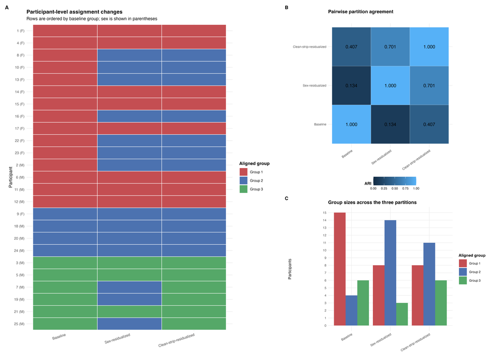

Participant-level transitions across the baseline, sex-residualized, and clean-strip-residualized exploratory partitions.

Pairwise agreement among the three exploratory partitions.

| comparison | ARI | same_aligned_label_n | different_aligned_label_n |
| --- | --- | --- | --- |
| Baseline vs Sex-residualized | 0.1341 | 15 | 10 |
| Baseline vs Clean-strip-residualized | 0.4071 | 18 | 7 |
| Sex-residualized vs Clean-strip-residualized | 0.7006 | 22 | 3 |

# 8. Consolidated publication tables

Consolidated summary of sex-associated and clean-strip sensitivity results.

| Source | Metric | Value |
| --- | --- | --- |
| Sex-associated variation | Sex x baseline partition Fisher p | 0.003 |
| Sex-associated variation | Sex x baseline partition Cramer’s V | 0.640 |
| Sex-associated variation | Cramer’s V 95% CI | 0.414 to 0.919 |
| Sex-associated variation | PC1 Wilcoxon raw p | 0.016 |
| Sex-associated variation | PC1 Wilcoxon BH-adjusted p | 0.048 |
| Sex-associated variation | PC1 rank-biserial correlation (F vs M) | -0.564 |
| Sex-associated variation | PC1 Hedges g (F minus M) | -1.174 |
| Sex-residualized sensitivity | ARI vs baseline | 0.134 |
| Sex-residualized sensitivity | Aligned group sizes | 8/14/3 |
| Sex-residualized sensitivity | Participants changing aligned assignment | 10 |
| Sex-residualized sensitivity | Average silhouette | 0.338 |
| Sex-residualized sensitivity | Sex x residualized partition Fisher p | 0.282 |
| Clean-strip technical reproducibility | Minimum pairwise Pearson r | 0.999989 |
| Clean-strip technical reproducibility | Minimum pairwise Spearman rho | 0.999982 |
| Clean-strip technical reproducibility | Integrated absorbance CV (%) | 0.819 |
| Clean-strip technical reproducibility | Median pointwise CV (%) | 0.854 |
| Clean-strip technical reproducibility | 95th percentile pointwise CV (%) | 1.174 |
| Clean-strip-direction sensitivity | ARI vs baseline | 0.407 |
| Clean-strip-direction sensitivity | Participants changing aligned assignment | 7 |
| Clean-strip-direction sensitivity | Average silhouette | 0.371 |
| Cross-sensitivity comparison | ARI: sex-residualized vs clean-strip-residualized | 0.701 |

# 9. Supplementary diagnostic figures

## Repeated-subsampling consensus

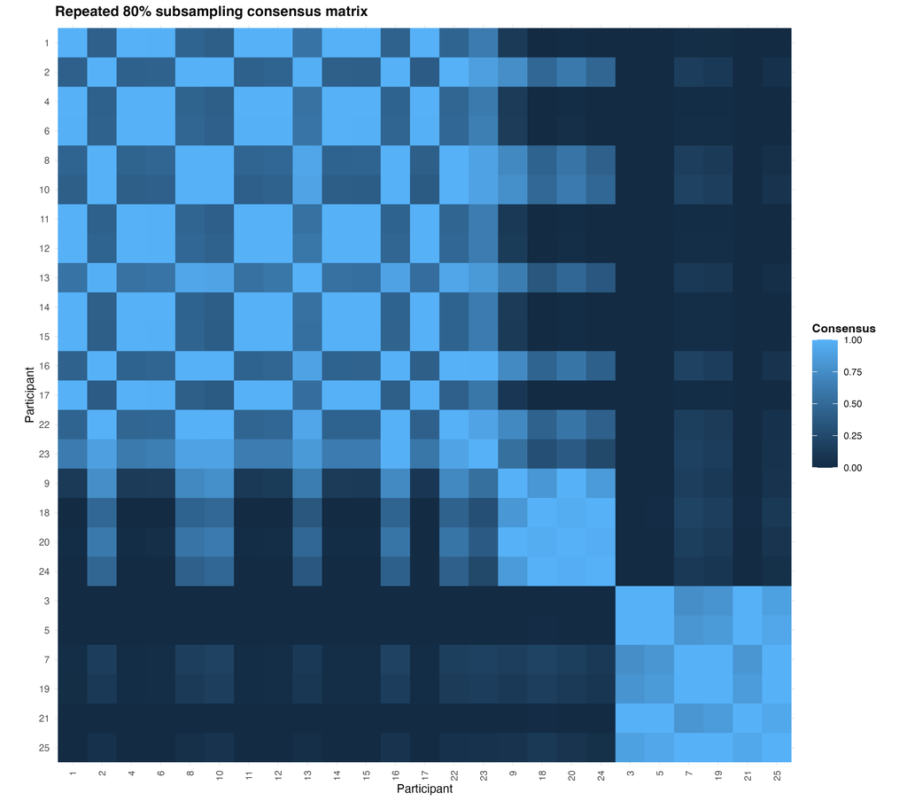

Pairwise consensus across repeated 80% subsamples.

## Group-specific bootstrap stability

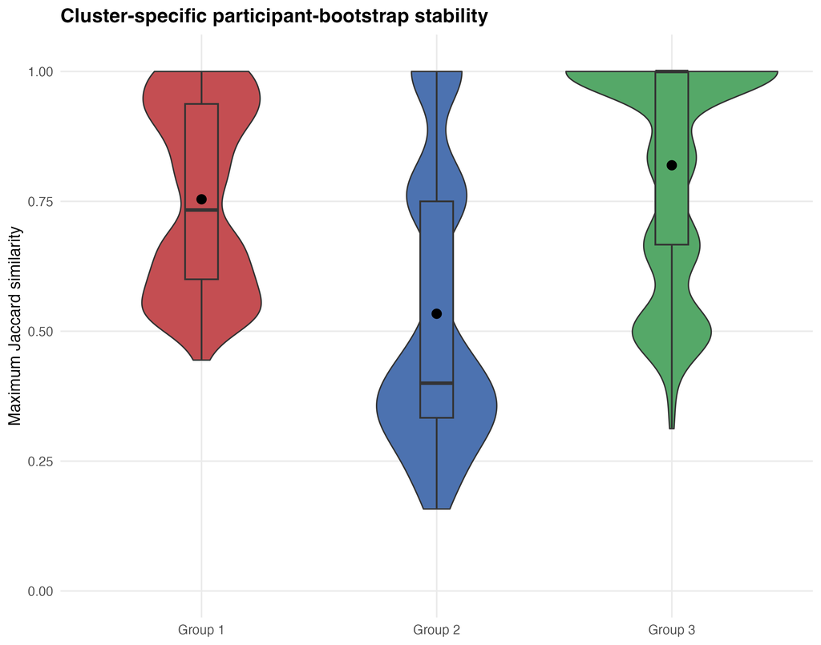

Group-specific Jaccard stability across participant-bootstrap iterations.

## Descriptive raw spectra by exploratory group

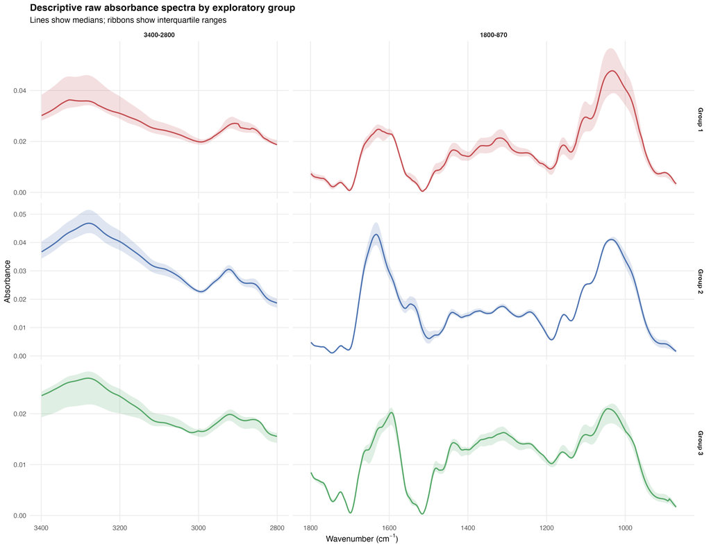

Descriptive median and interquartile raw absorbance spectra by exploratory group.

## Invariance across independent strip directions

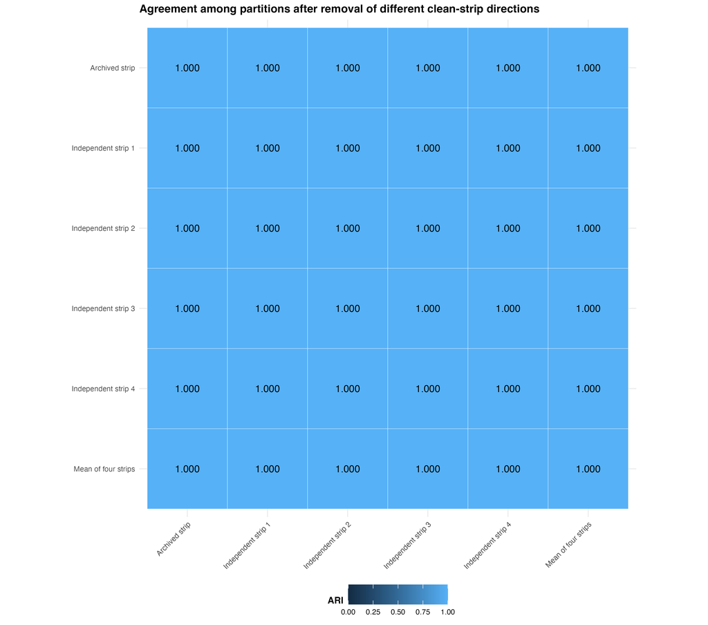

Agreement among partitions obtained after removing alternative independently measured clean-strip directions.

# 10. Output manifest and machine-readable audit

The publication builder generated **30 outputs**: **3 main tables**, **7 supplementary tables**, **6 main figures**, and **4 supplementary figures**. Both PNG and PDF versions are retained for each figure.

Publication-output manifest generated by R/07_tables_figures.R.

| category | path | exists | size_bytes | md5 |
| --- | --- | --- | --- | --- |
| main_table | tables/Table1_pediatric_cohort_characteristics.csv | TRUE | 660 | c42016c4ff17e675e36f7327ff977c5d |
| main_table | tables/Table2_exploratory_partition_stability.csv | TRUE | 1132 | 7a0dd59e580ec842c167a4dda74b79c6 |
| main_table | tables/Table3_sex_and_substrate_sensitivity.csv | TRUE | 1399 | c3ed836e49b263dd5651af929277a8a6 |
| supplement_table | supplement/TableS1_cluster_stability_detailed.csv | TRUE | 2543 | c9fcf0c2c8fb893b2b8eb99a6171491a |
| supplement_table | supplement/TableS2_PC1_PC3_sex_associations_BH.csv | TRUE | 1236 | de5e4efdccf0e55d411a64284571abce |
| supplement_table | supplement/TableS3_clean_strip_technical_reproducibility.csv | TRUE | 523 | 18fdbd6593d93facca95aa0d932659d9 |
| supplement_table | supplement/TableS4_clean_strip_direction_sensitivity.csv | TRUE | 639 | 94a523653a2a5c0bfa489f8060d72fbb |
| supplement_table | supplement/TableS5_participant_assignment_transitions.csv | TRUE | 1566 | 2155e43c0be21cf3ab8bd45ce615da1f |
| supplement_table | supplement/TableS6_pairwise_partition_agreement.csv | TRUE | 246 | 442264b30f9970e0b2c423c515122c05 |
| supplement_table | supplement/TableS7_PCA_eigenvector_loadings_PC1_PC3.csv | TRUE | 73301 | a66c0ac783036f7505076629a703e63c |
| main_figure | figures/Figure1_analytical_workflow.png | TRUE | 998446 | 7fc55fd8d686da2763e6bf5a690a25b6 |
| main_figure | figures/Figure1_analytical_workflow.pdf | TRUE | 7535 | 6d70e014632a94650c6a4b0138f77bca |
| main_figure | figures/Figure2_spectral_structure_and_PCA_profiles.png | TRUE | 1183677 | 470aaa1f32db16f9d0196a671f364567 |
| main_figure | figures/Figure2_spectral_structure_and_PCA_profiles.pdf | TRUE | 120363 | 2c6885c90ba16266fc8f5aac4c578c11 |
| main_figure | figures/Figure3_partition_selection_and_stability.png | TRUE | 629814 | 98d3c6c0cfd9384c4e2630d639bba1c9 |
| main_figure | figures/Figure3_partition_selection_and_stability.pdf | TRUE | 25859 | 4bdb9849c9e75741daa66593ed857f7f |
| main_figure | figures/Figure4_sex_associated_variation.png | TRUE | 505489 | 17f32b08667a24b683ee98293902444e |
| main_figure | figures/Figure4_sex_associated_variation.pdf | TRUE | 15004 | 205bd6fa56c849c569d632b11654978d |
| main_figure | figures/Figure5_clean_strip_reproducibility_and_sensitivity.png | TRUE | 676603 | d491e84f041c59f45e3e579f2be42e90 |
| main_figure | figures/Figure5_clean_strip_reproducibility_and_sensitivity.pdf | TRUE | 33377 | fb70e285a20aa1851f66edf98ce2b2c8 |
| main_figure | figures/Figure6_partition_assignment_transitions.png | TRUE | 397016 | ad977638be2e672b9559342d883daaae |
| main_figure | figures/Figure6_partition_assignment_transitions.pdf | TRUE | 7819 | f32c9a7f8e5e037d00b30efbead4a71c |
| supplement_figure | figures/FigureS1_consensus_heatmap.png | TRUE | 112057 | 4512e84bd544bdfed32c1d8918e37546 |
| supplement_figure | figures/FigureS1_consensus_heatmap.pdf | TRUE | 10419 | 837711b55eb417830e774aa8de1e14f9 |
| supplement_figure | figures/FigureS2_bootstrap_group_Jaccard.png | TRUE | 182315 | 39a9cf307e8e1c2a7965ffeacf226cc4 |
| supplement_figure | figures/FigureS2_bootstrap_group_Jaccard.pdf | TRUE | 21757 | 9e0b3036ec1426bcab13febf82a53b79 |
| supplement_figure | figures/FigureS3_descriptive_group_spectra.png | TRUE | 610042 | 80f027e6707e18c89a41730a8dd8ad1e |
| supplement_figure | figures/FigureS3_descriptive_group_spectra.pdf | TRUE | 43570 | 2454df3837c030c0f2d9ed01bd5bbb6e |
| supplement_figure | figures/FigureS4_clean_strip_direction_invariance.png | TRUE | 160667 | 44cf9d23c366d70c8232c0f7a1c2a390 |
| supplement_figure | figures/FigureS4_clean_strip_direction_invariance.pdf | TRUE | 6191 | 16633c5323bb73cbf9b8fc1c1891aac2 |

The machine-readable report snapshot is written to:

```
tables/08_reproducibility_report_key_numbers.csv
```

The automated scope checks are written to:

```
tables/08_reproducibility_report_scope_checks.csv
```

# 11. Reproducibility interpretation

The numerical results support five bounded conclusions:

1. The pediatric measurements contain structured multivariate spectral variation.
2. The three-group representation is useful descriptively but shows specification dependence and uneven group stability.
3. Sex-associated spectral variation contributes substantially to the baseline organization.
4. The unused strips are highly reproducible, while removal of an independently defined strip-aligned direction materially changes participant assignments.
5. The current design does not justify treating the exploratory groups as discrete biological or clinical entities.

Machine-readable numerical snapshot used for manuscript reconstruction.

| section | metric | value_numeric | value_text |
| --- | --- | --- | --- |
| Data | Participants | 25.000000 | 25 |
| Data | Spectral variables | 793.000000 | 793 |
| Baseline PCA | PC1 variance (%) | 48.276344 | 48.276 |
| Baseline PCA | PC2 variance (%) | 32.370416 | 32.370 |
| Baseline PCA | PC3 variance (%) | 8.635065 | 8.635 |
| Baseline PCA | Cumulative variance PC1-PC3 (%) | 89.281825 | 89.282 |
| Baseline PCA | Average silhouette | 0.434249 | 0.434 |
| Baseline partition | Group 1 n | 15.000000 | 15 |
| Baseline partition | Group 2 n | 4.000000 | 4 |
| Baseline partition | Group 3 n | 6.000000 | 6 |
| Stability | Leave-one-out mean ARI | 0.810712 | 0.811 |
| Stability | Leave-one-out median ARI | 1.000000 | 1.000 |
| Stability | Leave-one-out exact recovery proportion | 0.680000 | 0.680 |
| Stability | 80% subsampling mean ARI | 0.641811 | 0.642 |
| Stability | 80% subsampling median ARI | 0.580934 | 0.581 |
| Stability | Within-group mean consensus | 0.748859 | 0.749 |
| Stability | Between-group mean consensus | 0.114849 | 0.115 |
| Stability | Bootstrap mean ARI | 0.579428 | 0.579 |
| Stability | Bootstrap median ARI | 0.504810 | 0.505 |
| Sex-associated variation | Sex-partition Fisher p | 0.002995 | 0.003 |
| Sex-associated variation | Sex-partition Cramer’s V | 0.640095 | 0.640 |
| Sex-associated variation | PC1 raw p | 0.015972 | 0.016 |
| Sex-associated variation | PC1 BH-adjusted p | 0.047915 | 0.048 |
| Sex-associated variation | PC1 rank-biserial correlation | -0.564103 | -0.564 |
| Sex-associated variation | PC1 Hedges g | -1.174311 | -1.174 |
| Sex-associated variation | Sex-residualized ARI vs baseline | 0.134140 | 0.134 |
| Sex-associated variation | Sex-residualized average silhouette | 0.338050 | 0.338 |
| Sex-associated variation | Participants changing after sex residualization | 10.000000 | 10 |
| Clean-strip analysis | Minimum pairwise Pearson r | 0.999989 | 0.999989 |
| Clean-strip analysis | Minimum pairwise Spearman rho | 0.999982 | 0.999982 |
| Clean-strip analysis | Integrated absorbance CV (%) | 0.818766 | 0.819 |
| Clean-strip analysis | Median pointwise CV (%) | 0.854203 | 0.854 |
| Clean-strip analysis | 95th percentile pointwise CV (%) | 1.174046 | 1.174 |
| Clean-strip analysis | Residualized ARI vs baseline | 0.407115 | 0.407 |
| Clean-strip analysis | Residualized average silhouette | 0.371266 | 0.371 |
| Clean-strip analysis | Participants changing after residualization | 7.000000 | 7 |
| Partition comparison | ARI: sex-residualized vs clean-strip-residualized | 0.700627 | 0.701 |
| Partition comparison | Participants changing in either sensitivity analysis | 10.000000 | 10 |
| Partition comparison | Participants changing in both sensitivity analyses | 7.000000 | 7 |